# Impact of Weather Calamities on Economy and Health in the U.S

Amudha

### Synopsis

This report,aim to **analyze the impact of different weather events** on public health and economy based on the storm database collected from the U.S. National Oceanic and Atmospheric Administration’s (NOAA) from 1950 - 2011. We will use the estimates of fatalities, injuries, property and crop damage to decide which types of event are most harmful to the population health and economy.

### Data

The data comes from U.S. National Oceanic and Atmospheric Administration in csv, compressed in bz2 and following is the link to download the data and also relevant documents.

1. [The main NOAA database](https://d396qusza40orc.cloudfront.net/repdata%2Fdata%2FStormData.csv.bz2)
2. [National Weather Service Storm Data Documentation](https://d396qusza40orc.cloudfront.net/repdata%2Fpeer2_doc%2Fpd01016005curr.pdf)
3. [National Climatic Data Center Storm Events FAQ](https://d396qusza40orc.cloudfront.net/repdata%2Fpeer2_doc%2FNCDC%20Storm%20Events-FAQ%20Page.pdf)

The NOAA database is quite large. It contains nearly a million observation of 37 variables. This calls for some data cleaning and data processing to speed up the analysis.

## Pre-Requisite

Load required R libraries

```r
library(plyr)
library(ggplot2)
library(car)
```

### Data Processing

For reproducability purposes, **load and clean the data from it’s original source**

```r
 # Check to see if the data file exists in the working directory
if (!file.exists("repdata_data_StormData.csv")) {

    # Check to see if the zipped file exists in the working directory
    if (!file.exists("repdata_data_StormData.csv.bz2")) {

        # Download thye zipped file from the WEB and unzip it
        website <- "https://d396qusza40orc.cloudfront.net/repdata%2Fdata%2FStormData.csv.bz2"
        download.file(website, filename, mode = "wb")
    }

    # Unzip the file
    bzfile("repdata_data_StormData.csv.bz2")

}
```

For reasons of effectiveness, speed and computer memory management, transform the data by **reading only the specific columns of the data**, which are needed for analysis.

```r
sublist <- c("EVTYPE", "FATALITIES", "INJURIES", "PROPDMG", "PROPDMGEXP", "CROPDMG",
    "CROPDMGEXP")
df <- read.table("./repdata_data_StormData.csv", sep = ",", header = TRUE)
df <- subset(df, select = sublist)

## change column names to lower case
names(df) <- tolower(names(df))
```

## Impact of Severe Weather on Public Health

### Data Analysis

**Get casualties (sum of fatalities and injuries) for each event type** and store it in a new dataframe

```r
## sum of fatalities and injuries for each type of event
df.casualties <- ddply(df, "evtype", summarize, fatalities = sum(fatalities),
    injuries = sum(injuries), casualties = sum(fatalities + injuries))
```

```r
## sort the casualties by the top casualties.
df.casualties <- arrange(df.casualties, desc(casualties), desc(fatalities),
    desc(injuries))

## reorder event type levels, will show a nicer plot
df.casualties$evtype <- reorder(df.casualties$evtype, -df.casualties$casualties)

## temporary dataframe containing the top ten
temp <- df.casualties[1:10, ]

## new dataframe containing the sum for all rows but the top ten ones
otherevt <- data.frame(evtype = "All Other Calamities", fatalities = sum(df.casualties$fatalities[11:length(df.casualties)]),
    injuries = sum(df.casualties$injuries[11:length(df.casualties)]), casualties = sum(df.casualties$casualties[11:length(df.casualties)]))
## merge the two data frames
df.casualties <- rbind(temp, otherevt)
colnames(df.casualties) = c("Events", "Fatalities","Injuries","Total casualties")
```

**Table of Weather Events that have severe impact to U.S Population**

```r
knitr::kable(df.casualties)
```

| Events | Fatalities | Injuries | Total casualties |
| --- | --- | --- | --- |
| TORNADO | 5633 | 91346 | 96979 |
| EXCESSIVE HEAT | 1903 | 6525 | 8428 |
| TSTM WIND | 504 | 6957 | 7461 |
| FLOOD | 470 | 6789 | 7259 |
| LIGHTNING | 816 | 5230 | 6046 |
| HEAT | 937 | 2100 | 3037 |
| FLASH FLOOD | 978 | 1777 | 2755 |
| ICE STORM | 89 | 1975 | 2064 |
| THUNDERSTORM WIND | 133 | 1488 | 1621 |
| WINTER STORM | 206 | 1321 | 1527 |
| All Other Calamities | 3877 | 21817 | 25694 |

### Result

To visualize the impact of severe weather on the public health we will make a bar graph of the impact of the most significant weather events on the public health comparing with each casualties

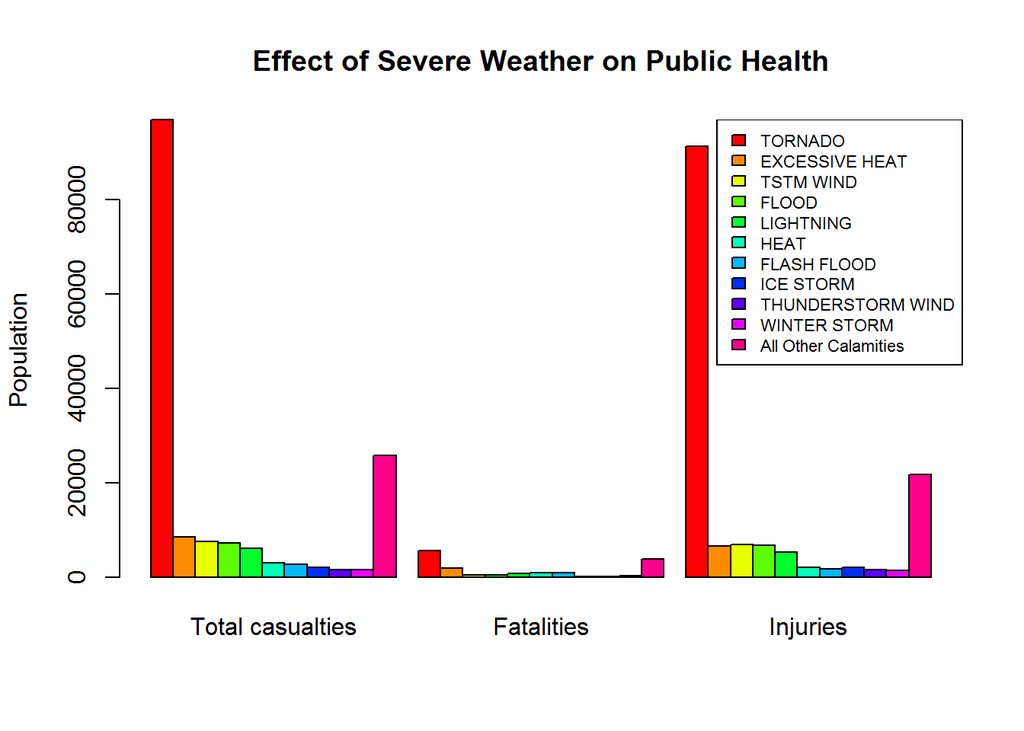

```r
casualties.matrix = as.matrix(df.casualties[,c(4,2,3)])
barplot(casualties.matrix, beside = TRUE, col=rainbow(11),
        main="Effect of Severe Weather on Public Health", ylab="Population")
legend("topright", legend=df.casualties$Events, cex=0.7, fill=rainbow(11))
```

From the graphs it can be seen that more public is affected by **Tornadoes** as there were more injuries and fatalities as well.Even number of public affected by all other calamaties were less comparing to Tornadoes

## Impact of Severe Weather on Economy

### Data Analysis

**Get Total Damage Value (sum of Property Damage Value and Crop Damage Value) for each event type** and store it in a new dataframe

```r
## we'll start by subsetting on the economic variables
df.econ <- df[, -c(2, 3)]

## recode property and crop damage columns to thier dollar exponent value
df.econ$propdmgexp2 <- recode(df.econ$propdmgexp, "'h'=1e2;'H'=1e2;'k'=1e3;'K'=1e3;'m'=1e6;'M'=1e6;'b'=1e9;'B'=1e9;'0'=1;'1'=10;'2'=100;'3'=1000;'4'=10000;'5'=100000;'6'=1000000;'7'=10000000;'8'=100000000;'-'=0;'?'=0;'+'=0;''=0")
df.econ$cropdmgexp2 <- recode(df.econ$cropdmgexp, "'h'=100;'H'=100;'k'=1000;'K'=1000;'m'=1000000;'M'=1000000;'b'=1000000000;'B'=1000000000;'0'=1;'1'=10;'2'=100;'3'=1000;'4'=10000;'5'=100000;'6'=1000000;'7'=10000000;'8'=100000000;'-'=0;'?'=0;'+'=0;''=0")

## Add new columns for dollar value of property and crop damages
df.econ$propdmgval <- df.econ$propdmg * as.numeric(levels(df.econ$propdmgexp2))[df.econ$propdmgexp2]
df.econ$cropdmgval <- df.econ$cropdmg * as.numeric(levels(df.econ$cropdmgexp2))[df.econ$cropdmgexp2]
df.econ$totaldmgval <- df.econ$propdmgval + df.econ$cropdmgval

## Add the total damage values and the event type
df.econ2 <- df.econ[, c("evtype", "propdmgval", "cropdmgval", "totaldmgval")]
df.econ2 <- arrange(df.econ2, desc(totaldmgval))
df.econ3 <- ddply(df.econ2, "evtype", summarize, propdmgval = sum(propdmgval),
    cropdmgval = sum(cropdmgval), totaldmg = sum(propdmgval + cropdmgval))
df.econ3 <- arrange(df.econ3, desc(totaldmg))
df.econ3$evtype <- reorder(df.econ3$evtype, -df.econ3$totaldmg)
```

```r
## temporary dataframe containing the top ten
n <- 10
temp <- df.econ3[1:n, ]
## new dataframe containing the sum for all rows but the top ten ones
otherevt <- data.frame(evtype = "All Other Calamities", propdmgval = sum(df.econ3$propdmgval[n +
    1:length(df.econ3)]), cropdmgval = sum(df.econ3$cropdmgval[n + 1:length(df.econ3)]),
    totaldmg = sum(df.econ3$totaldmg[n + 1:length(df.econ3)]))
## merge the two data frames
df.econ.list <- rbind(temp, otherevt)
```

**Table of Top Weather Events that cause severe damage to Property and Crop in terms of U.S dollars**

```r
df.econ.tab <- df.econ.list
colnames(df.econ.tab) = c("Events", "Property Damage Value","Crop Damage Value","Total Damage Value")
knitr::kable(df.econ.tab)
```

| Events | Property Damage Value | Crop Damage Value | Total Damage Value |
| --- | --- | --- | --- |
| FLOOD | 144657709800 | 5661968450 | 150319678250 |
| HURRICANE/TYPHOON | 69305840000 | 2607872800 | 71913712800 |
| TORNADO | 56947380614 | 414953270 | 57362333884 |
| STORM SURGE | 43323536000 | 5000 | 43323541000 |
| HAIL | 15735267456 | 3025954470 | 18761221926 |
| FLASH FLOOD | 16822673772 | 1421317100 | 18243990872 |
| DROUGHT | 1046106000 | 13972566000 | 15018672000 |
| HURRICANE | 11868319010 | 2741910000 | 14610229010 |
| RIVER FLOOD | 5118945500 | 5029459000 | 10148404500 |
| ICE STORM | 3944927860 | 5022113500 | 8967041360 |
| All Other Calamities | 24427548061 | 1639334100 | 26066882161 |

### Result

To visualize the impact of severe weather on the economy we will make a bar graph of the impact of the most significant weather events on the economy:

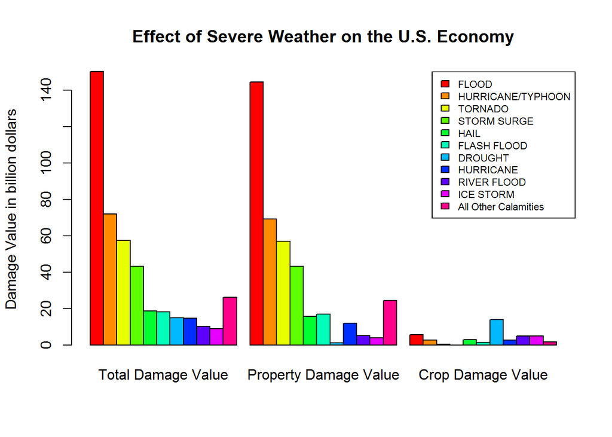

```r
damage.matrix = as.matrix(df.econ.tab[,c(4,2,3)])/1000000000 # to show as billion $
barplot(damage.matrix, beside = TRUE, col=rainbow(11),
        main="Effect of Severe Weather on the U.S. Economy", ylab="Damage Value in billion dollars")
legend("topright", legend=df.econ.tab$Events, cex=0.7, fill=rainbow(11))
```

From the graphs it can be seen that U.S Economy is affected by **Flood** .Even damage value of all other calamaties were less comparing to Flood.